# IBM HR Analytics Employee Attrition & Performance

# Skewness

## Assessing the Skewness of Data

```python
attrition.skew()
```

```
Age                         0.413286
DailyRate                  -0.003519
DistanceFromHome            0.958118
Education                  -0.289681
EmployeeNumber              0.016574
EnvironmentSatisfaction    -0.321654
HourlyRate                 -0.032311
JobInvolvement             -0.498419
JobLevel                    1.025401
JobSatisfaction            -0.329672
MonthlyIncome               1.406633
MonthlyRate                 0.050458
NumCompaniesWorked          1.026471
PercentSalaryHike           1.024921
PerformanceRating           1.921883
RelationshipSatisfaction   -0.302828
StockOptionLevel            0.968980
TotalWorkingYears           1.117172
TrainingTimesLastYear       0.553124
WorkLifeBalance            -0.552480
YearsAtCompany              1.764529
YearsInCurrentRole          0.917363
YearsSinceLastPromotion     1.984290
YearsWithCurrManager        0.833451
dtype: float64
```

Highly Positively Skewed Variables (right-skewed)

Most of the variables are slightly or moderately right-skewed and a few are highly right-skewed. Only a handful are left-skewed (moderately), or a few have little to no skewness.

```python
attrition.kurtosis()
```

```
Age                        -0.404145
DailyRate                  -1.203823
DistanceFromHome           -0.224833
Education                  -0.559115
EmployeeNumber             -1.223179
EnvironmentSatisfaction    -1.202521
HourlyRate                 -1.196398
JobInvolvement              0.270999
JobLevel                    0.399152
JobSatisfaction            -1.222193
MonthlyIncome               1.209173
MonthlyRate                -1.082101
NumCompaniesWorked          0.010214
PercentSalaryHike           2.242843
PerformanceRating           1.695939
RelationshipSatisfaction   -1.184814
StockOptionLevel            0.364634
TotalWorkingYears           0.918270
TrainingTimesLastYear       0.494993
WorkLifeBalance             0.419460
YearsAtCompany              3.935509
YearsInCurrentRole          0.477421
YearsSinceLastPromotion     3.612673
YearsWithCurrManager        0.171058
dtype: float64
```

Notable Values of Kurtosis:

1. Years Since Last Promotion = 3.61
1. Years At Company = 3.94

Indicates that the distribution is more peaked and has more extreme values than a normal distribution.

- This has implications for statistical analyses since the presence of extreme values can affect the validity of certain assumptions and tests.
- Need to examine the data for outliers and potential sources of bias that may be driving the kurtosis value.

Several variables have negative kurtosis, values less than zero, which can indicate that the data has a platykurtic distribution, which means thinner tails than a normal distribution and fewer extreme positive or negative values.

### Monthly Income

```python
attrition['MonthlyIncome'].skew()
 #excessive positive skewnesss = 1.41

 #means that the tail of the distribution extends to the right

 #more extreme values on the right side of the distribution

 # also indicated that the majority of the values are located on the left side of the distribution
```

```
1.4066333833818945
```

```python
attrition['MonthlyIncome'].kurtosis()

#a positive but low value of kurtosis (less than 3) = 1.21

#indicates that the distribution is a bit more peaked than a normal distribution and that the tails are more heavily distributed

#this makes sense because the data is right skewed and right tailed

#this value can also be indicative of the presence of more extreme values or outliers
```

```
1.2091727376450954
```

### Years In Current Role

```python
attrition['YearsInCurrentRole'].skew()
# positive skew = 0.92
# means that the tail of the distribution extends to the right
# more extreme values on the right side of the distribution
# also indicated that the majority of the values are located on the left side of the distribution
```

```
0.9173631562908262
```

```python
attrition['YearsInCurrentRole'].kurtosis()

#a positive but low value of kurtosis (less than 1) = 0.48

#indicates that the distribution is a bit more peaked than a normal distribution and that the tails are more heavily distributed
```

```
0.47742077351356293
```

## Transforming Skewed Data

### Changing Data Types

```python
#Change data type of Gender column; convert genders into 1 and 0
attrition.Gender[attrition.Gender == 'Male'] = 1
attrition.Gender[attrition.Gender == 'Female'] = 0
```

```python
#Show results of above for gender column
print(attrition['Gender'])
```

```
0       0
1       1
2       1
3       0
4       1
       ..
1465    1
1466    1
1467    1
1468    1
1469    1
Name: Gender, Length: 1470, dtype: object
```

```python
#Change the data type of the gender column to int
attrition['Gender'] = attrition['Gender'].astype(int)
```

### Normalize Skewed Data

```python
def normalize(column):
    upper = column.max()
    lower = column.min()
    y = (column - lower)/(upper-lower)
    return y
```

```python
YearsAtCompany_normalized = normalize(attrition.YearsAtCompany)
YearsAtCompany_normalized.describe()
```

```
count    1470.000000
mean        0.175204
std         0.153163
min         0.000000
25%         0.075000
50%         0.125000
75%         0.225000
max         1.000000
Name: YearsAtCompany, dtype: float64
```

```python
TotalWorkingHours_normalized = normalize(attrition.TotalWorkingYears)
TotalWorkingHours_normalized.describe()
```

```
count    1470.00000
mean        0.28199
std         0.19452
min         0.00000
25%         0.15000
50%         0.25000
75%         0.37500
max         1.00000
Name: TotalWorkingYears, dtype: float64
```

```python
PerformanceRating_normalized = normalize(attrition.PerformanceRating)
PerformanceRating_normalized.describe()
```

```
count     1470.0
unique       2.0
top          0.0
freq      1244.0
Name: PerformanceRating, dtype: float64
```

```python
NumCompaniesWorked_normalized = normalize(attrition.NumCompaniesWorked)
NumCompaniesWorked_normalized.describe()
```

```
count    1470.000000
mean        0.299244
std         0.277557
min         0.000000
25%         0.111111
50%         0.222222
75%         0.444444
max         1.000000
Name: NumCompaniesWorked, dtype: float64
```

### Binning the Age column

```python
#Binning the age column
attrition.loc[attrition['Age'].between(18, 30, 'both'), 'age_range'] = '18-30'
attrition.loc[attrition['Age'].between(30, 40, 'right'), 'age_range'] = '30-40'
attrition.loc[attrition['Age'].between(40, 50, 'right'), 'age_range'] = '40-50'
attrition.loc[attrition['Age'].between(50, 60, 'right'), 'age_range'] = '50-60'
```

```python
#value counts of age groups/bins
attrition.age_range.value_counts()
```

```
30-40    619
18-30    386
40-50    322
50-60    143
Name: age_range, dtype: int64
```

## Metrics and KPIs

### Employee Attrition Rate

```python
#employees who left the organization (Attrition = 'Yes')
turnover = attrition[attrition['Attrition'] == 'Yes']
turnover
```

|  | Age | Attrition | BusinessTravel | DailyRate | Department | DistanceFromHome | Education | EducationField | EmployeeNumber | EnvironmentSatisfaction | Gender | HourlyRate | JobInvolvement | JobLevel | JobRole | JobSatisfaction | MaritalStatus | MonthlyIncome | MonthlyRate | NumCompaniesWorked | Over18 | OverTime | PercentSalaryHike | PerformanceRating | RelationshipSatisfaction | StockOptionLevel | TotalWorkingYears | TrainingTimesLastYear | WorkLifeBalance | … |
| --- | --- | --- | --- | --- | --- | --- | --- | --- | --- | --- | --- | --- | --- | --- | --- | --- | --- | --- | --- | --- | --- | --- | --- | --- | --- | --- | --- | --- | --- | --- |
| 0 | 41 | Yes | Travel_Rarely | 1102 | Sales | 1 | 2 | Life Sciences | 1 | 2 | 0 | 94 | 3 | 2 | Sales Executive | 4 | Single | 5993.0 | 19479.0 | 8 | Y | Yes | 11.0 | 3 | 1 | 0 | 8 | 0 | 1 | … |
| 2 | 37 | Yes | Travel_Rarely | 1373 | Research & Development | 2 | 2 | Other | 4 | 4 | 1 | 92 | 2 | 1 | Laboratory Technician | 3 | Single | 2090.0 | 2396.0 | 6 | Y | Yes | 15.0 | 3 | 2 | 0 | 7 | 3 | 3 | … |
| 14 | 28 | Yes | Travel_Rarely | 103 | Research & Development | 24 | 3 | Life Sciences | 19 | 3 | 1 | 50 | 2 | 1 | Laboratory Technician | 3 | Single | 2028.0 | 12947.0 | 5 | Y | Yes | 14.0 | 3 | 2 | 0 | 6 | 4 | 3 | … |
| 21 | 36 | Yes | Travel_Rarely | 1218 | Sales | 9 | 4 | Life Sciences | 27 | 3 | 1 | 82 | 2 | 1 | Sales Representative | 1 | Single | 3407.0 | 6986.0 | 7 | Y | No | 23.0 | 4 | 2 | 0 | 10 | 4 | 3 | … |
| 24 | 34 | Yes | Travel_Rarely | 699 | Research & Development | 6 | 1 | Medical | 31 | 2 | 1 | 83 | 3 | 1 | Research Scientist | 1 | Single | 2960.0 | 17102.0 | 2 | Y | No | 11.0 | 3 | 3 | 0 | 8 | 2 | 3 | … |
| ... | ... | ... | ... | ... | ... | ... | ... | ... | ... | ... | ... | ... | ... | ... | ... | ... | ... | ... | ... | ... | ... | ... | ... | ... | ... | ... | ... | ... | ... | … |
| 1438 | 23 | Yes | Travel_Frequently | 638 | Sales | 9 | 3 | Marketing | 2023 | 4 | 1 | 33 | 3 | 1 | Sales Representative | 1 | Married | 1790.0 | 26956.0 | 1 | Y | No | 19.0 | 3 | 1 | 1 | 1 | 3 | 2 | … |
| 1442 | 29 | Yes | Travel_Rarely | 1092 | Research & Development | 1 | 4 | Medical | 2027 | 1 | 1 | 36 | 3 | 1 | Research Scientist | 4 | Married | 4787.0 | 26124.0 | 9 | Y | Yes | 14.0 | 3 | 2 | 3 | 4 | 3 | 4 | … |
| 1444 | 56 | Yes | Travel_Rarely | 310 | Research & Development | 7 | 2 | Technical Degree | 2032 | 4 | 1 | 72 | 3 | 1 | Laboratory Technician | 3 | Married | 2339.0 | 3666.0 | 8 | Y | No | 11.0 | 3 | 4 | 1 | 14 | 4 | 1 | … |
| 1452 | 50 | Yes | Travel_Frequently | 878 | Sales | 1 | 4 | Life Sciences | 2044 | 2 | 1 | 94 | 3 | 2 | Sales Executive | 3 | Divorced | 6728.0 | 14255.0 | 7 | Y | No | 12.0 | 3 | 4 | 2 | 12 | 3 | 3 | … |
| 1461 | 50 | Yes | Travel_Rarely | 410 | Sales | 28 | 3 | Marketing | 2055 | 4 | 1 | 39 | 2 | 3 | Sales Executive | 1 | Divorced | 10854.0 | 16586.0 | 4 | Y | Yes | 13.0 | 3 | 2 | 1 | 20 | 3 | 3 | … |

237 rows × 34 columns

```python
#number of employees who left
t_count = len(turnover)
t_count
```

```
237
```

```python
#total number of employees
total= attrition['EmployeeNumber'].count()

total
```

```
1470
```

```python
turnover_rate = (t_count/total)*100
turnover_rate
```

```
16.122448979591837
```

The yearly attrition rate of employees is 16%.

Attrition Rate By Department

```python
attrition_by_dept= (attrition.groupby("Department")["Attrition"].value_counts(normalize=True).loc[:,"Yes"])*100

attrition_by_dept.columns = ['Department','Attrition Rate']

attrition_by_dept.round(2)
```

```
Department
Human Resources           19.05
Research & Development    13.84
Sales                     20.63
Name: Attrition, dtype: float64
```

The Sales department appears to have the highest attrition rate at 20.63%

Attrition Rate by Job Role

```python
attrition_by_role= (attrition.groupby("JobRole")["Attrition"].value_counts(normalize=True).loc[:,"Yes"])*100

attrition_by_role.columns = ['Job Role','Attrition Rate']

attrition_by_role.round(2).sort_values(ascending=False)

#Sales Reps have the highest attrition rate followed by Lab Techs and Human Resources
```

```
JobRole
Sales Representative         39.76
Laboratory Technician        23.94
Human Resources              23.08
Sales Executive              17.48
Research Scientist           16.10
Manufacturing Director        6.90
Healthcare Representative     6.87
Manager                       4.90
Research Director             2.50
Name: Attrition, dtype: float64
```

### Employee Satisfaction

Job Satisfaction

```python
J_satisfaction= attrition.groupby('JobSatisfaction')['EmployeeNumber'].count().reset_index()

J_satisfaction.columns= ['Job Satisfaction','Counts']
```

```python
J_sum= J_satisfaction['Counts'].sum()
```

```python
average= ((J_satisfaction['Counts'])/(J_sum)*100)

J_satisfaction['Average']= average.round(2)

J_satisfaction['Average'] = J_satisfaction['Average'].astype(int)

J_satisfaction
```

|  | Job Satisfaction | Counts | Average |
| --- | --- | --- | --- |
| 0 | 1 | 289 | 19 |
| 1 | 2 | 280 | 19 |
| 2 | 3 | 442 | 30 |
| 3 | 4 | 459 | 31 |

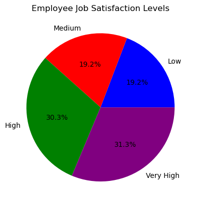

```python
mylabels = ["Low", "Medium", "High", "Very High"]
plt.pie(J_satisfaction["Average"], labels = mylabels,autopct='%1.1f%%',colors=['blue', 'red', 'green', 'purple'])
plt.title ("Employee Job Satisfaction Levels")
plt.show()
```

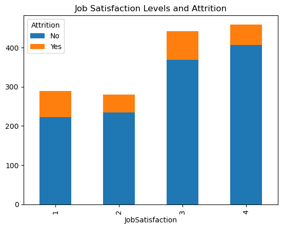

```python
attrition.pivot_table(index=["JobSatisfaction"], columns='Attrition', values='EmployeeNumber', aggfunc='count').plot(kind='bar', stacked=True)

plt.title("Job Satisfaction Levels and Attrition")
```

Environment Satisfaction

```python
E_satisfaction= attrition.groupby('EnvironmentSatisfaction')['EmployeeNumber'].count().reset_index()

E_satisfaction.columns= ['Environment Satisfaction','Counts']
```

```python
E_sum= E_satisfaction['Counts'].sum()

E_sum

average2= ((E_satisfaction['Counts'])/(E_sum))*100

E_satisfaction['Average']= average2.round(2)

E_satisfaction['Average'] = E_satisfaction['Average'].astype(int)

E_satisfaction
```

|  | Environment Satisfaction | Counts | Average |
| --- | --- | --- | --- |
| 0 | 1 | 284 | 19 |
| 1 | 2 | 287 | 19 |
| 2 | 3 | 453 | 30 |
| 3 | 4 | 446 | 30 |

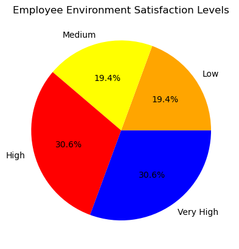

```python
mylabels = ["Low", "Medium", "High", "Very High"]
plt.pie(E_satisfaction["Average"], labels = mylabels,autopct='%1.1f%%',colors=['orange', 'yellow', 'red', 'blue'])
plt.title ("Employee Environment Satisfaction Levels")
plt.show()
```

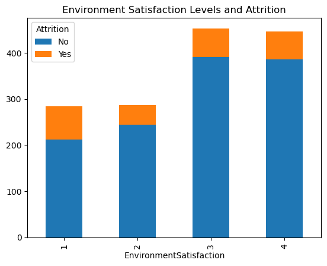

```python
attrition.pivot_table(index=["EnvironmentSatisfaction"], columns='Attrition', values='EmployeeNumber', aggfunc='count').plot(kind='bar', stacked=True)

plt.title("Environment Satisfaction Levels and Attrition")
```

Average Job Satisfaction by Department

```python
attrition["JobSatisfaction"]=attrition["JobSatisfaction"].astype(int)

js_d= attrition.groupby("Department")["JobSatisfaction"].mean().round(2).reset_index()
js_d
```

|  | Department | JobSatisfaction |
| --- | --- | --- |
| 0 | Human Resources | 2.60 |
| 1 | Research & Development | 2.73 |
| 2 | Sales | 2.75 |

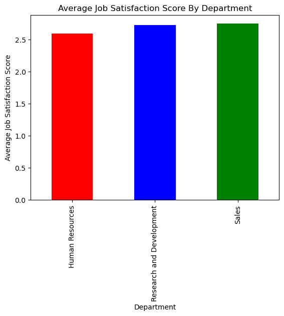

```python
colors = ["red","blue","green"]
ax= js_d["JobSatisfaction"].plot(kind="bar", x="Department",color=colors)

labels = ["Human Resources","Research and Development","Sales"]

ax.set_xticklabels(labels, rotation='vertical', fontsize=10)

ax.set_title("Average Job Satisfaction Score By Department")

ax.set_xlabel("Department")

ax.set_ylabel("Average Job Satisfaction Score")

plt.show()
```

```python
jb_jd= attrition.groupby("JobRole")["JobSatisfaction"].mean().round(2).reset_index()

jb_jd
```

|  | JobRole | JobSatisfaction |
| --- | --- | --- |
| 0 | Healthcare Representative | 2.79 |
| 1 | Human Resources | 2.56 |
| 2 | Laboratory Technician | 2.69 |
| 3 | Manager | 2.71 |
| 4 | Manufacturing Director | 2.68 |
| 5 | Research Director | 2.70 |
| 6 | Research Scientist | 2.77 |
| 7 | Sales Executive | 2.75 |
| 8 | Sales Representative | 2.73 |

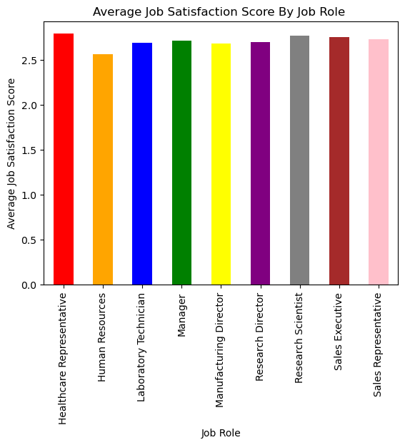

```python
colors = ["red","orange","blue","green","yellow","purple","grey","brown","pink","lightgreen"]
ax= jb_jd["JobSatisfaction"].plot(kind="bar", x="JobRole",color=colors)

labels = jb_jd["JobRole"]

ax.set_xticklabels(labels, rotation='vertical', fontsize=10)

ax.set_title("Average Job Satisfaction Score By Job Role ")

ax.set_xlabel("Job Role")

ax.set_ylabel("Average Job Satisfaction Score")

plt.show()
```

The average job satisfaction score by job role range from 2.5 to 3 which is medium for job roles, thus the scores don't vary much by job role.

### Overtime

```python
overtime = attrition[attrition['OverTime'] == 'Yes']

len(overtime) #416


total= attrition['EmployeeNumber'].count()

total.astype(int) # 1470

((len(overtime)/total)*100).round(2)

#28.3% of employees worked overtime.
```

```
28.3
```

```python
overtime_by_dept= (attrition.groupby("Department")["OverTime"].value_counts(normalize=True).loc[:,"Yes"])*100
overtime_by_dept.round(2)
```

```
Department
Human Resources           26.98
Research & Development    28.20
Sales                     28.70
Name: OverTime, dtype: float64
```

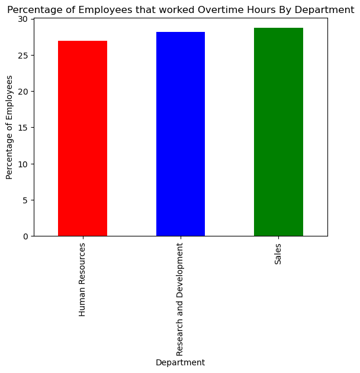

```python
colors = ["red","blue","green"]
ax= overtime_by_dept.plot(kind="bar", x="Department",color=colors)

labels = ["Human Resources","Research and Development","Sales"]

ax.set_xticklabels(labels, rotation='vertical', fontsize=10)

ax.set_title("Percentage of Employees that worked Overtime Hours By Department")

ax.set_xlabel("Department")

ax.set_ylabel("Percentage of Employees")

plt.show()

#there isnt a department wise disparity when it comes to overtime hours.
```

```python
overtime_by_role= (attrition.groupby("JobRole")["OverTime"].value_counts(normalize=True).loc[:,"Yes"])*100
overtime_by_role.round(2)
```

```
JobRole
Healthcare Representative    28.24
Human Resources              25.00
Laboratory Technician        23.94
Manager                      26.47
Manufacturing Director       26.90
Research Director            28.75
Research Scientist           33.22
Sales Executive              28.83
Sales Representative         28.92
Name: OverTime, dtype: float64
```

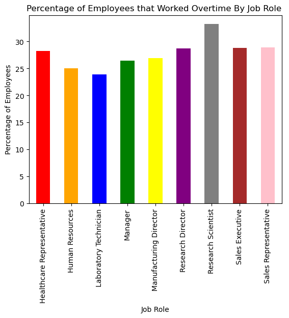

```python
colors = ["red","orange","blue","green","yellow","purple","grey","brown","pink"]
ax= overtime_by_role.plot(kind="bar", x="JobRole",color=colors)

labels = jb_jd["JobRole"]

ax.set_xticklabels(labels, rotation='vertical', fontsize=10)

ax.set_title("Percentage of Employees that Worked Overtime By Job Role ")

ax.set_xlabel("Job Role")

ax.set_ylabel("Percentage of Employees")

plt.show()
```